# R语言与数据可视化

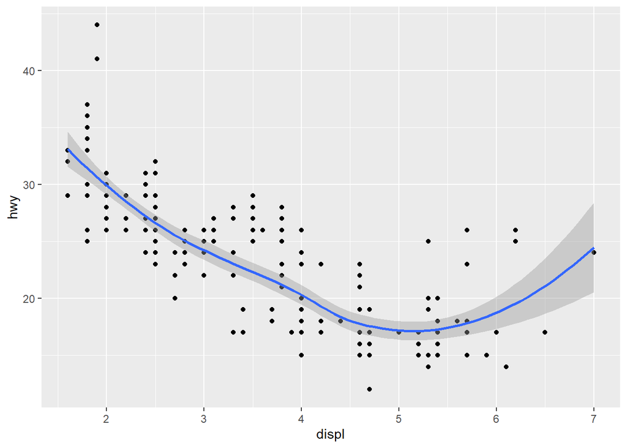

```r
# geom_smooth()：平滑曲线
ggplot(mpg, aes(x = displ, y = hwy)) +
  geom_point() +
  geom_smooth()
```

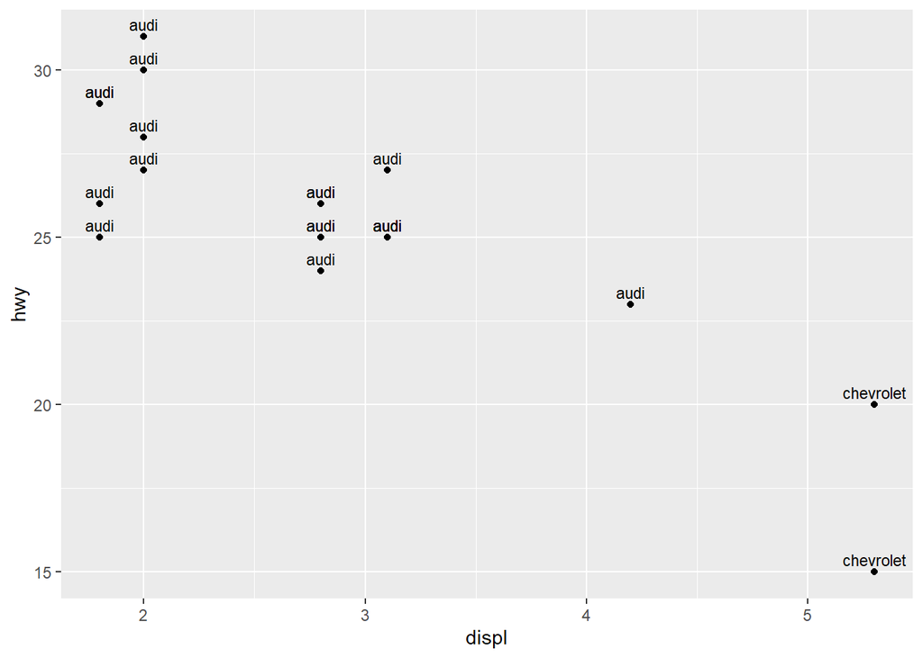

```r
# geom_text()：文本标签
ggplot(mpg[1:20, ], aes(x = displ, y = hwy)) +
  geom_point() +
  geom_text(aes(label = manufacturer), vjust = -0.5, size = 3)
```

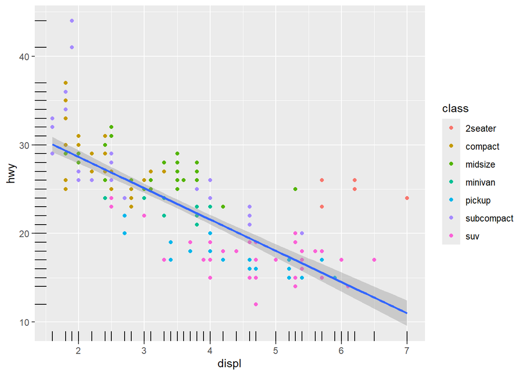

```r
# 组合多个几何对象
ggplot(mpg, aes(x = displ, y = hwy)) +
  geom_point(aes(color = class)) +
  geom_smooth(method = "lm", se = TRUE) +
  geom_rug()  # 边缘地毯图
```

**小结**：几何对象是图形的核心，可以通过`+`叠加多个图层。

## 2.5 统计变换

统计变换对数据进行计算后绘图。

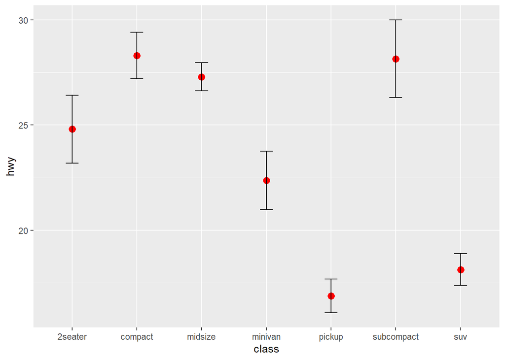

```r
# 统计变换示例

# stat_summary()：汇总统计
ggplot(mpg, aes(x = class, y = hwy)) +
  stat_summary(fun = mean, geom = "point", size = 3, color = "red") +
  stat_summary(fun.data = mean_cl_normal, geom = "errorbar", width = 0.2)
```

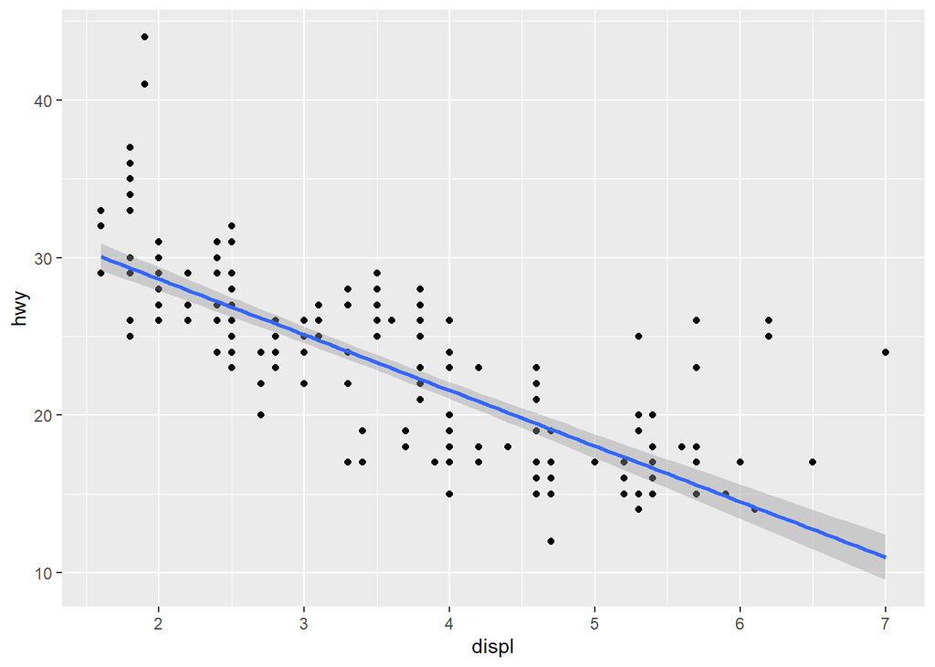

```r
# stat_smooth()：平滑曲线（geom_smooth()的底层）
ggplot(mpg, aes(x = displ, y = hwy)) +
  geom_point() +
  stat_smooth(method = "lm")
```

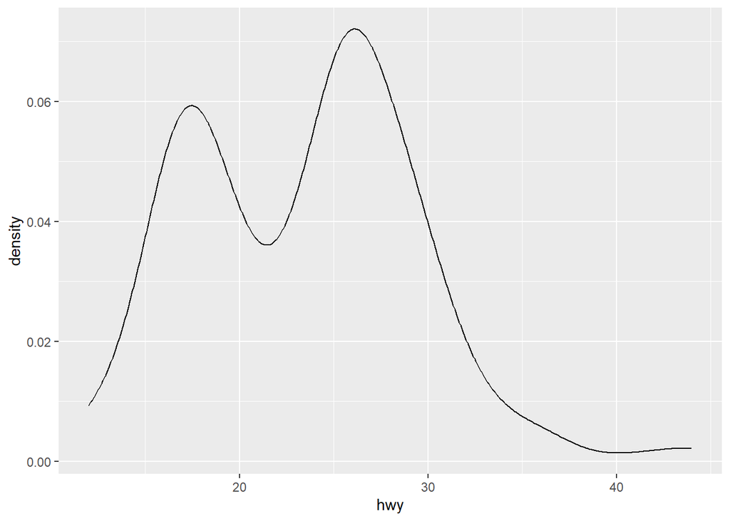

```r
# stat_density()：密度估计
ggplot(mpg, aes(x = hwy)) +
  stat_density(geom = "line")
```

```r
# stat_bin()：分箱计数（geom_histogram()的底层）
ggplot(mpg, aes(x = hwy)) +
  stat_bin(geom = "bar", bins = 20)
```

[output not shown]

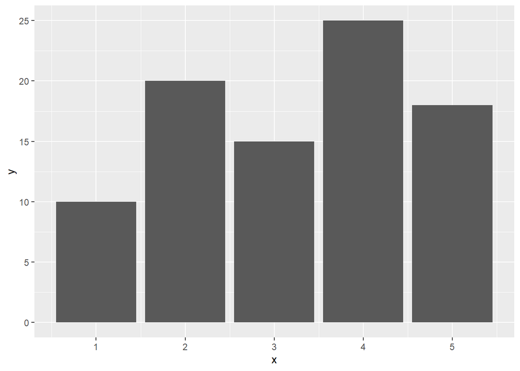

```r
# stat_identity()：直接使用数据值
df <- data.frame(x = 1:5, y = c(10, 20, 15, 25, 18))
ggplot(df, aes(x = x, y = y)) +
  stat_identity(geom = "bar")
```

**小结**：统计变换在绘图前对数据进行计算，每个geom都有对应的stat。

## 2.6 标度概述

标度控制数据到图形属性的映射。

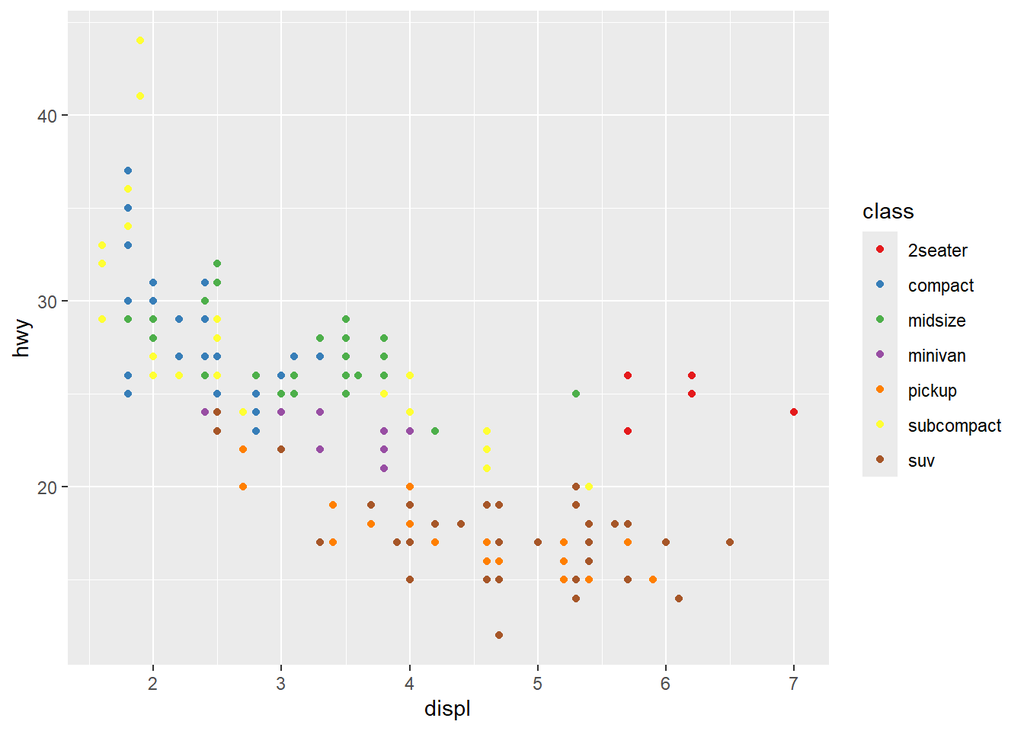

```r
# 标度控制图形属性

# 颜色标度
ggplot(mpg, aes(x = displ, y = hwy, color = class)) +
  geom_point() +
  scale_color_brewer(palette = "Set1")  # 使用ColorBrewer调色板
```

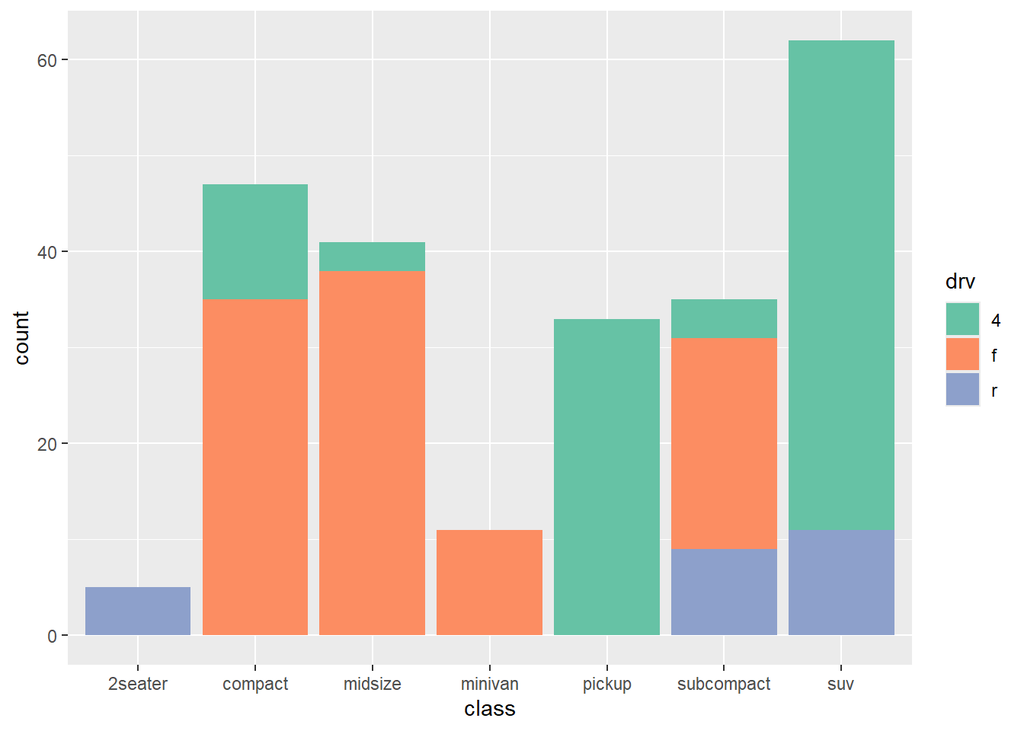

```r
# 填充标度
ggplot(mpg, aes(x = class, fill = drv)) +
  geom_bar() +
  scale_fill_brewer(palette = "Set2")
```

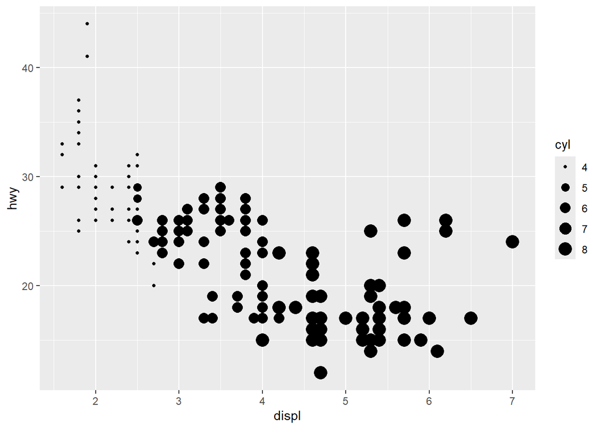

```r
# 大小标度
ggplot(mpg, aes(x = displ, y = hwy, size = cyl)) +
  geom_point() +
  scale_size(range = c(1, 5))
```

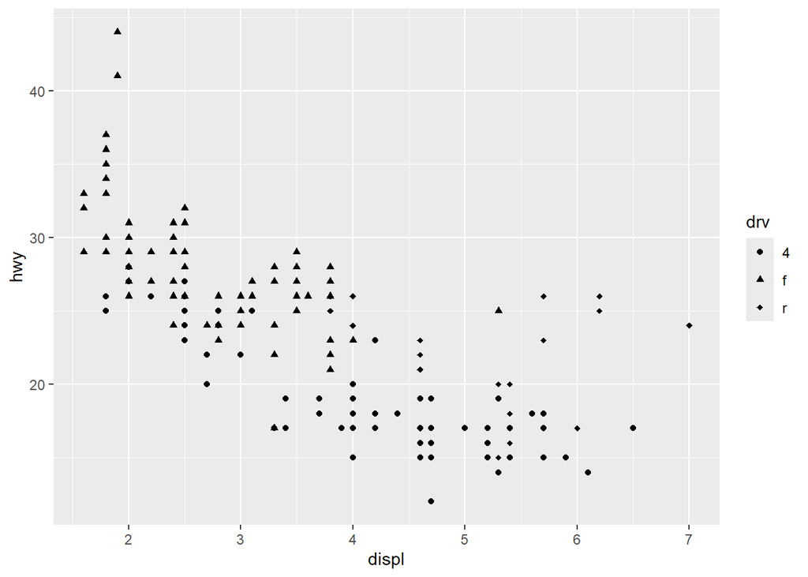

```r
# 形状标度
ggplot(mpg, aes(x = displ, y = hwy, shape = drv)) +
  geom_point() +
  scale_shape_manual(values = c(16, 17, 18))
```

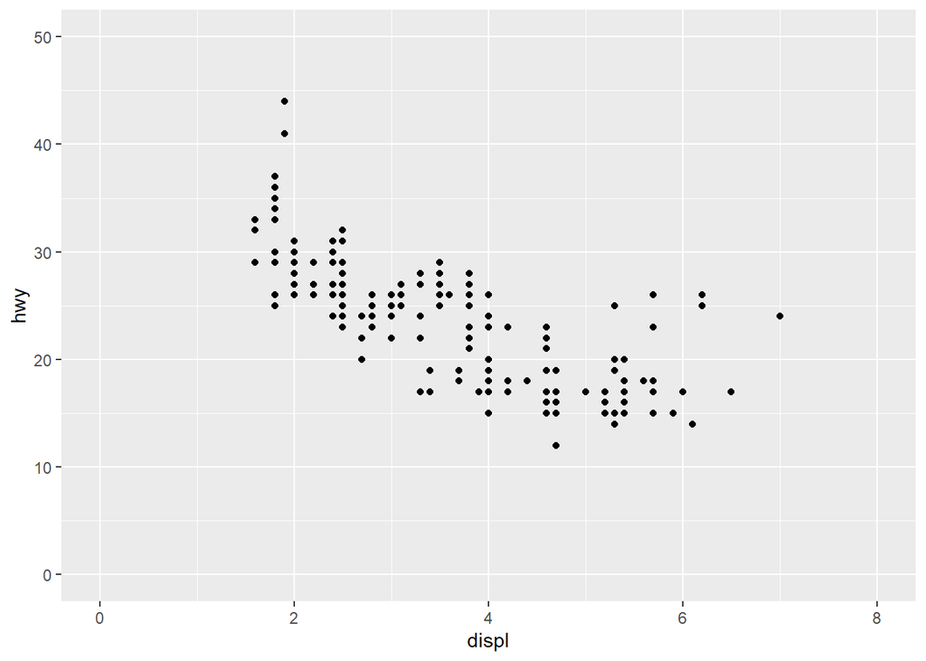

```r
# 坐标轴标度
ggplot(mpg, aes(x = displ, y = hwy)) +
  geom_point() +
  scale_x_continuous(limits = c(0, 8), breaks = seq(0, 8, 2)) +
  scale_y_continuous(limits = c(0, 50))
```

**小结**：标度函数以`scale_`开头，控制数据到图形属性的映射方式。

## 2.7 坐标系概述

坐标系定义数据到平面的映射。

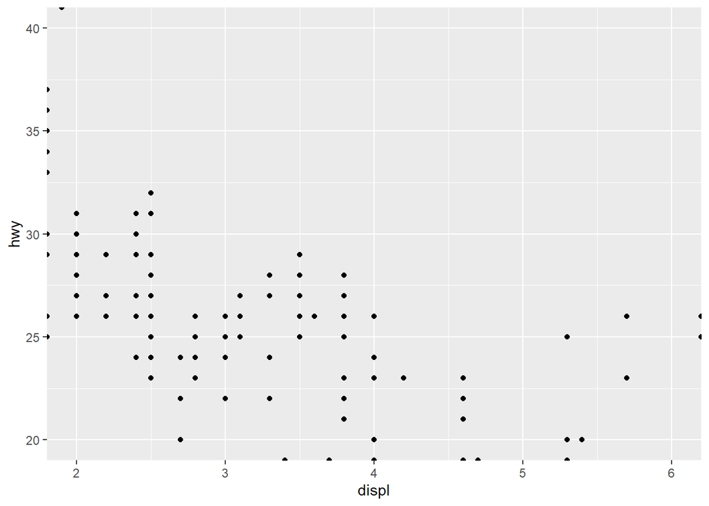

```r
# 常用坐标系

# coord_cartesian()：笛卡尔坐标系（默认）
ggplot(mpg, aes(x = displ, y = hwy)) +
  geom_point() +
  coord_cartesian(xlim = c(2, 6), ylim = c(20, 40))  # 缩放视图但不删除数据
```

```r
# coord_flip()：翻转坐标系
ggplot(mpg, aes(x = class, y = hwy)) +
  geom_boxplot() +
  coord_flip()
```

[output not shown]

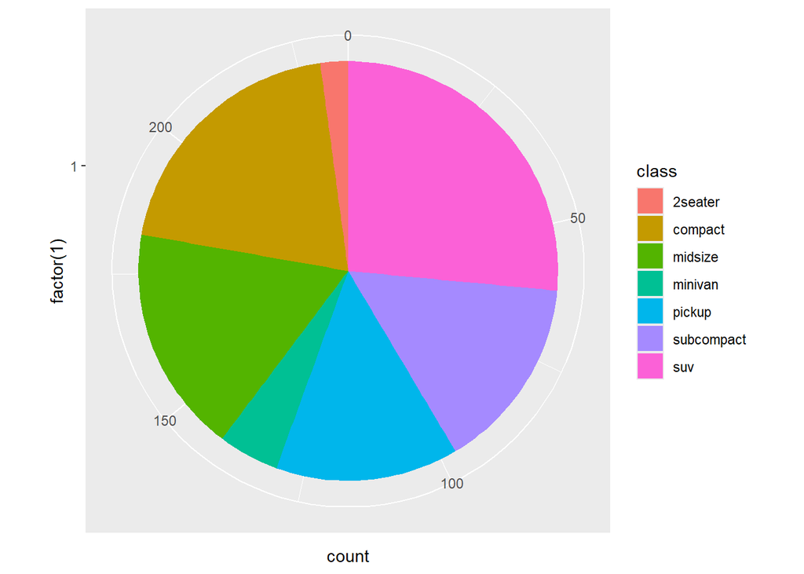

```r
# coord_polar()：极坐标系
ggplot(mpg, aes(x = factor(1), fill = class)) +
  geom_bar(width = 1) +
  coord_polar(theta = "y")  # 饼图
```

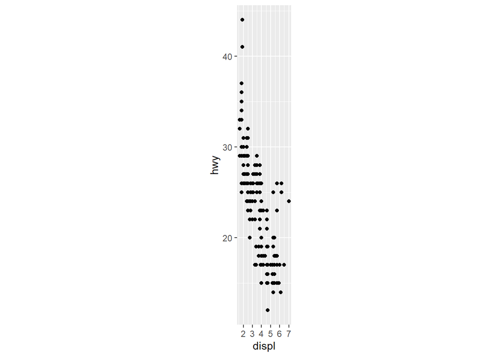

```r
# coord_fixed()：固定纵横比
ggplot(mpg, aes(x = displ, y = hwy)) +
  geom_point() +
  coord_fixed(ratio = 1)  # x轴和y轴单位长度相同
```

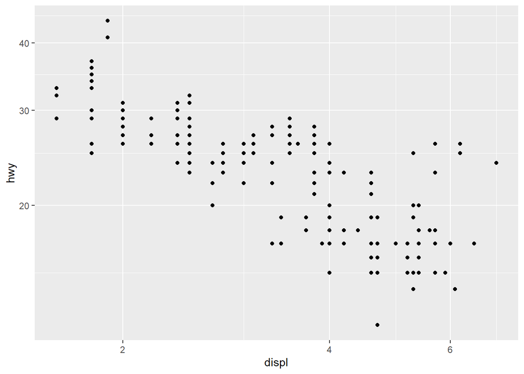

```r
# coord_trans()：坐标变换
ggplot(mpg, aes(x = displ, y = hwy)) +
  geom_point() +
  coord_trans(x = "log10", y = "log10")
```

**小结**：坐标系函数以`coord_`开头，控制数据到平面的映射方式。

## 2.8 分面概述

分面将数据分割成多个子图。

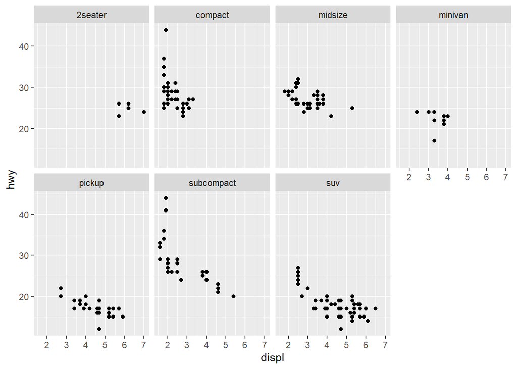

```r
# 分面类型

# facet_wrap()：按单变量分面
ggplot(mpg, aes(x = displ, y = hwy)) +
  geom_point() +
  facet_wrap(~ class, ncol = 4)  # 按class分面，4列
```

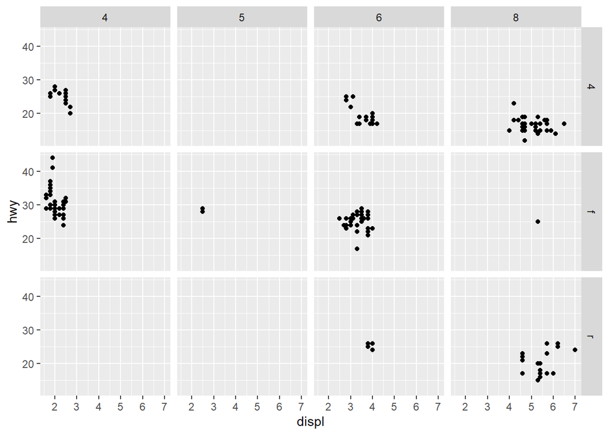

```r
# facet_grid()：按双变量分面
ggplot(mpg, aes(x = displ, y = hwy)) +
  geom_point() +
  facet_grid(drv ~ cyl)  # 行按drv，列按cyl
```

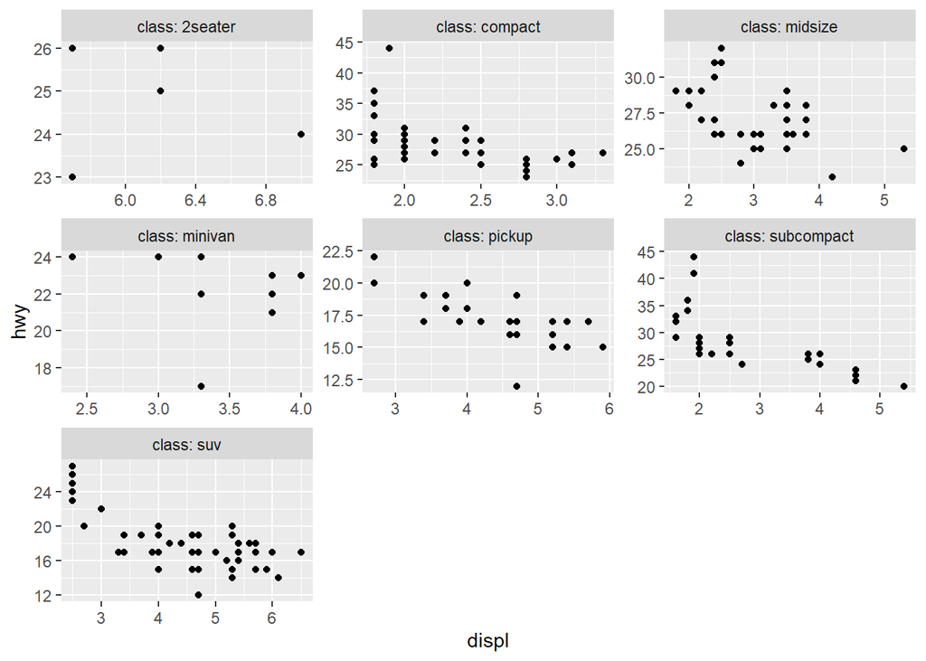

```r
# 分面参数
ggplot(mpg, aes(x = displ, y = hwy)) +
  geom_point() +
  facet_wrap(~ class,
             ncol = 3,           # 列数
             scales = "free",    # 各面板坐标轴独立
             labeller = label_both)  # 标签格式
```

**小结**：分面函数以`facet_`开头，用于创建多面板图形。

## 2.9 主题概述

主题控制图形的非数据元素。

```r
# 内置主题

p <- ggplot(mpg, aes(x = displ, y = hwy)) +
  geom_point()

# theme_gray()：默认灰色主题
p + theme_gray()
```

[output not shown]

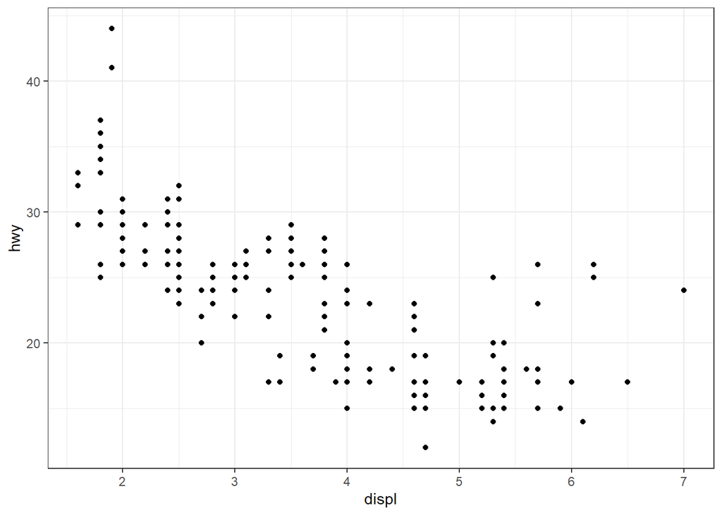

```r
# theme_bw()：黑白主题
p + theme_bw()
```

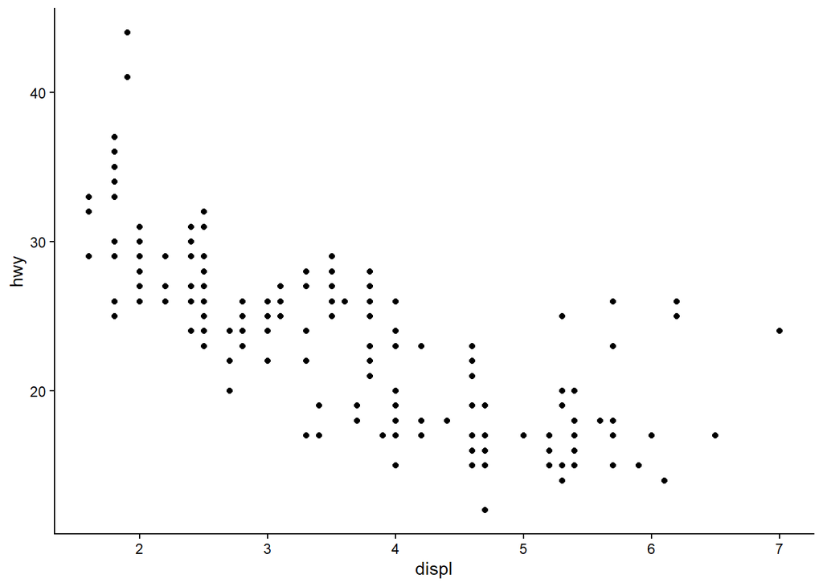

```r
# theme_classic()：经典主题
p + theme_classic()
```

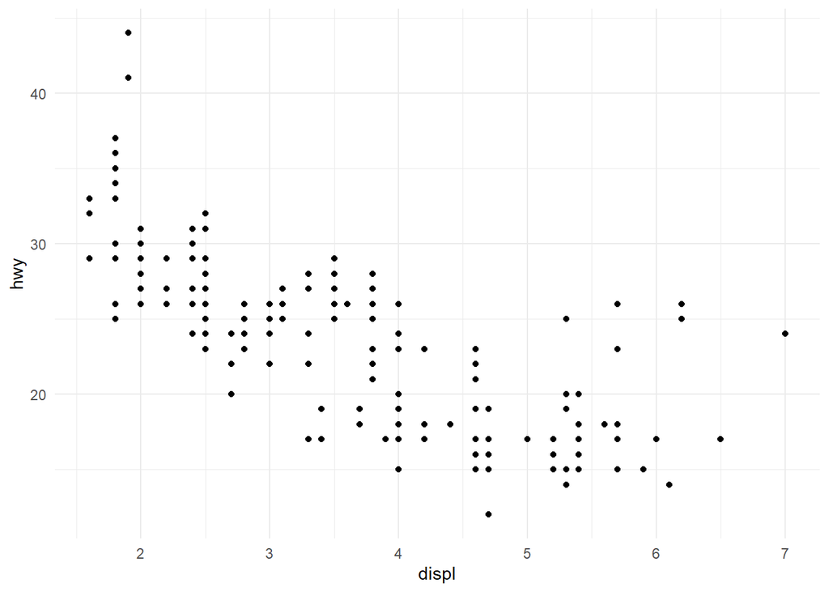

```r
# theme_minimal()：极简主题
p + theme_minimal()
```

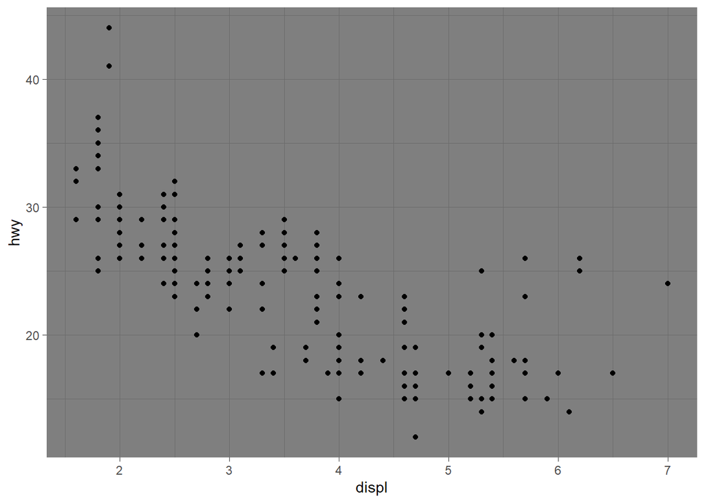

```r
# theme_dark()：深色主题
p + theme_dark()
```

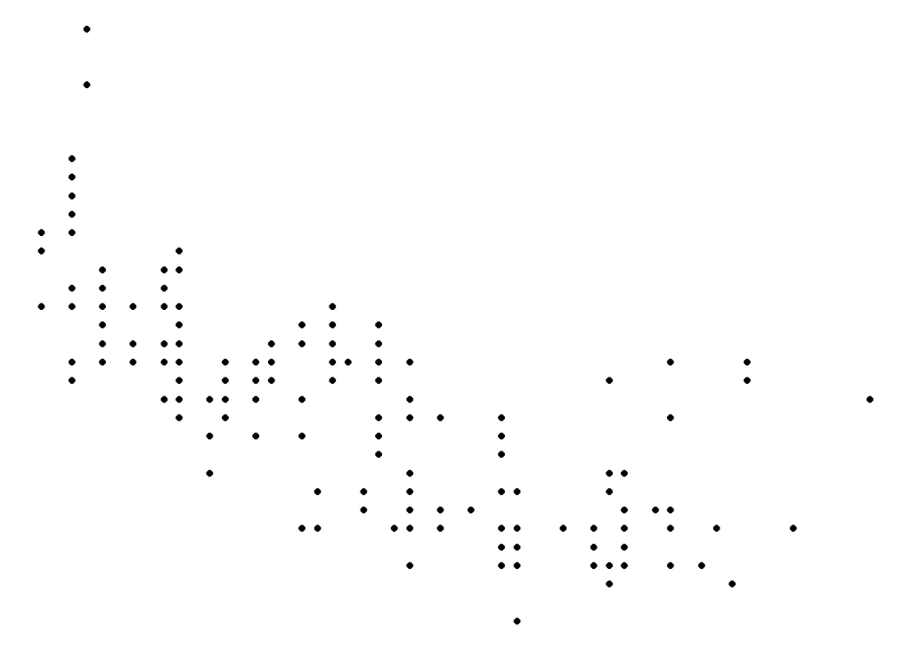

```r
# theme_void()：空白主题
p + theme_void()
```

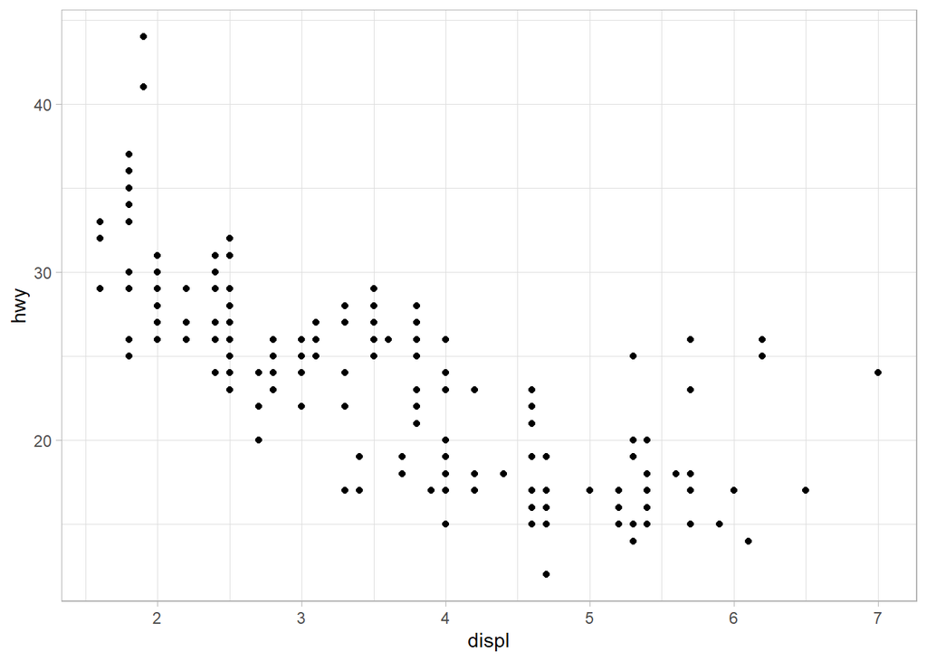

```r
# theme_light()：浅色主题
p + theme_light()
```

**小结**：主题控制图形的外观，ggplot2提供多种内置主题。

## 2.10 使用+符号构建图形

ggplot2使用`+`符号组合各组件。

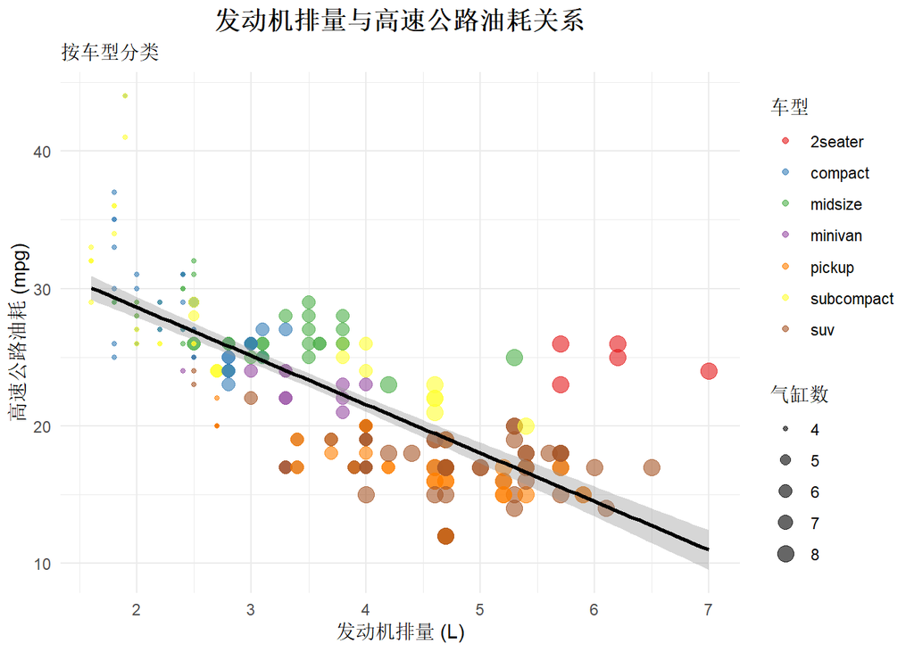

```r
# 使用+构建复杂图形

ggplot(mpg, aes(x = displ, y = hwy)) +
  # 图层1：散点图
  geom_point(aes(color = class, size = cyl), alpha = 0.6) +
  # 图层2：平滑曲线
  geom_smooth(method = "lm", se = TRUE, color = "black") +
  # 标度
  scale_color_brewer(palette = "Set1") +
  scale_size_continuous(range = c(1, 4)) +
  # 坐标轴标签
  labs(
    title = "发动机排量与高速公路油耗关系",
    subtitle = "按车型分类",
    x = "发动机排量 (L)",
    y = "高速公路油耗 (mpg)",
    color = "车型",
    size = "气缸数"
  ) +
  # 主题
  theme_minimal() +
  theme(
    plot.title = element_text(hjust = 0.5, size = 14, face = "bold"),
    legend.position = "right"
  )
```

**小结**：`+`符号将图形组件组合在一起，构建复杂图形。

## 第二章总结

| 组件 | 函数前缀 | 说明 |
| --- | --- | --- |
| 数据映射 | `aes()` | 数据到图形属性的映射 |
| 几何对象 | `geom_*()` | 图形的几何形状 |
| 统计变换 | `stat_*()` | 数据计算 |
| 标度 | `scale_*()` | 控制映射方式 |
| 坐标系 | `coord_*()` | 数据到平面的映射 |
| 分面 | `facet_*()` | 多面板图形 |
| 主题 | `theme_*()` | 非数据元素外观 |

# 第三章：常用统计图形（基础）

本章介绍ggplot2中常用的统计图形，包括散点图、折线图、柱状图、直方图等。

## 3.1 散点图

散点图用于展示两个连续变量之间的关系。

```r
# 基础散点图
ggplot(mpg, aes(x = displ, y = hwy)) +
  geom_point()
```

[output not shown]

```r
# 添加颜色映射
ggplot(mpg, aes(x = displ, y = hwy, color = class)) +
  geom_point()
```

[output not shown]

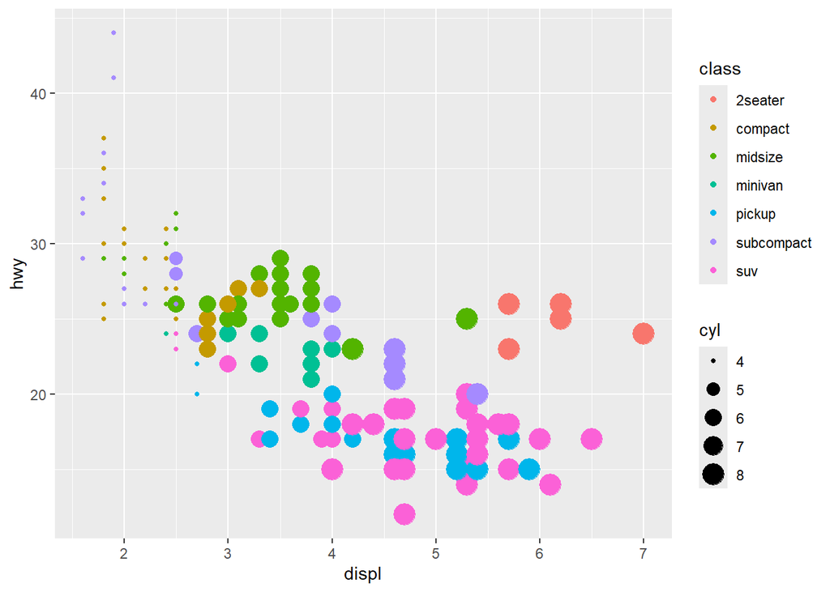

```r
# 添加大小映射
ggplot(mpg, aes(x = displ, y = hwy, color = class, size = cyl)) +
  geom_point()
```

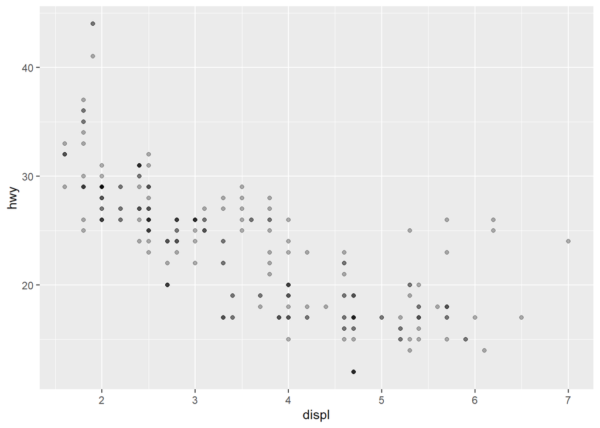

```r
# 设置透明度（处理重叠点）
ggplot(mpg, aes(x = displ, y = hwy)) +
  geom_point(alpha = 0.3)
```

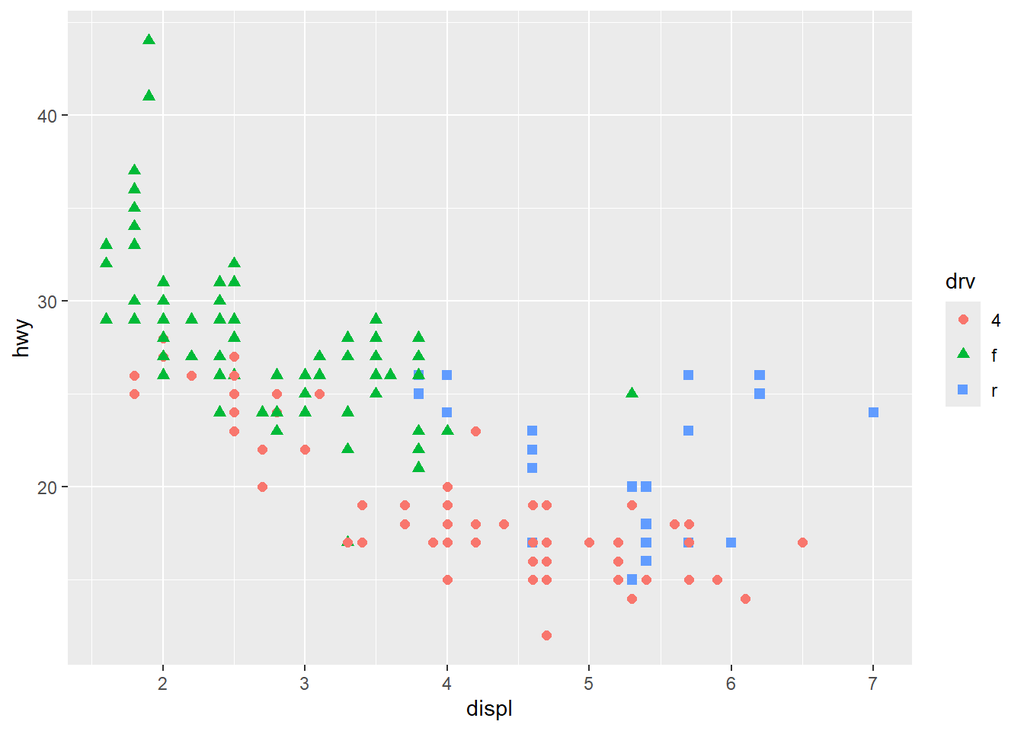

```r
# 使用形状区分组别
ggplot(mpg, aes(x = displ, y = hwy, shape = drv, color = drv)) +
  geom_point(size = 2)
```

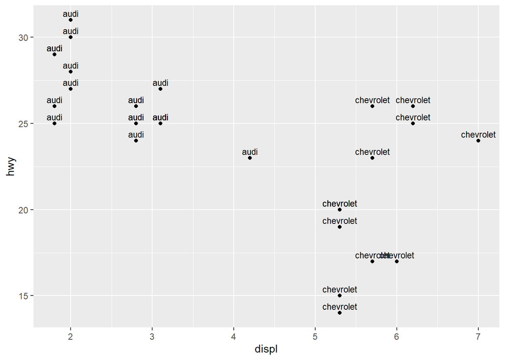

```r
# 添加文本标签
ggplot(mpg[1:30, ], aes(x = displ, y = hwy, label = manufacturer)) +
  geom_point() +
  geom_text(vjust = -0.5, size = 3)
```

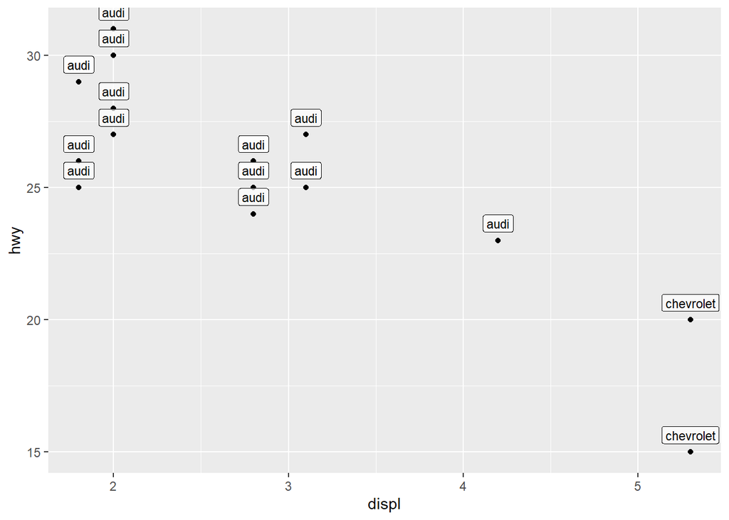

```r
# 使用geom_label()添加带背景的标签
ggplot(mpg[1:20, ], aes(x = displ, y = hwy, label = manufacturer)) +
  geom_point() +
  geom_label(vjust = -0.5, size = 3, alpha = 0.7)
```

```r
# 散点图矩阵（使用GGally包）
# library(GGally)
# ggpairs(mpg[, c("displ", "hwy", "cty", "cyl")])
```

**小结**：散点图是最常用的图形之一，可以通过颜色、大小、形状展示多维信息。

## 3.2 折线图

折线图用于展示数据随时间或有序变量的变化趋势。

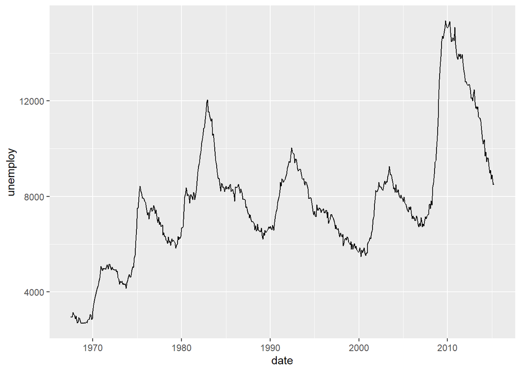

```r
# 基础折线图
ggplot(economics, aes(x = date, y = unemploy)) +
  geom_line()
```

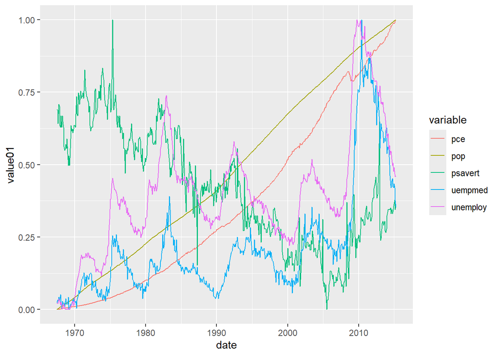

```r
# 多条折线
ggplot(economics_long, aes(x = date, y = value01, color = variable)) +
  geom_line()
```

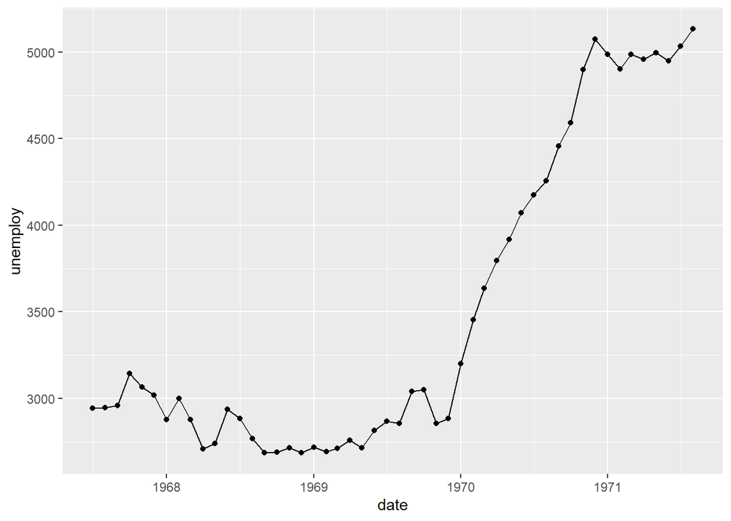

```r
# 添加点
ggplot(economics[1:50, ], aes(x = date, y = unemploy)) +
  geom_line() +
  geom_point()
```

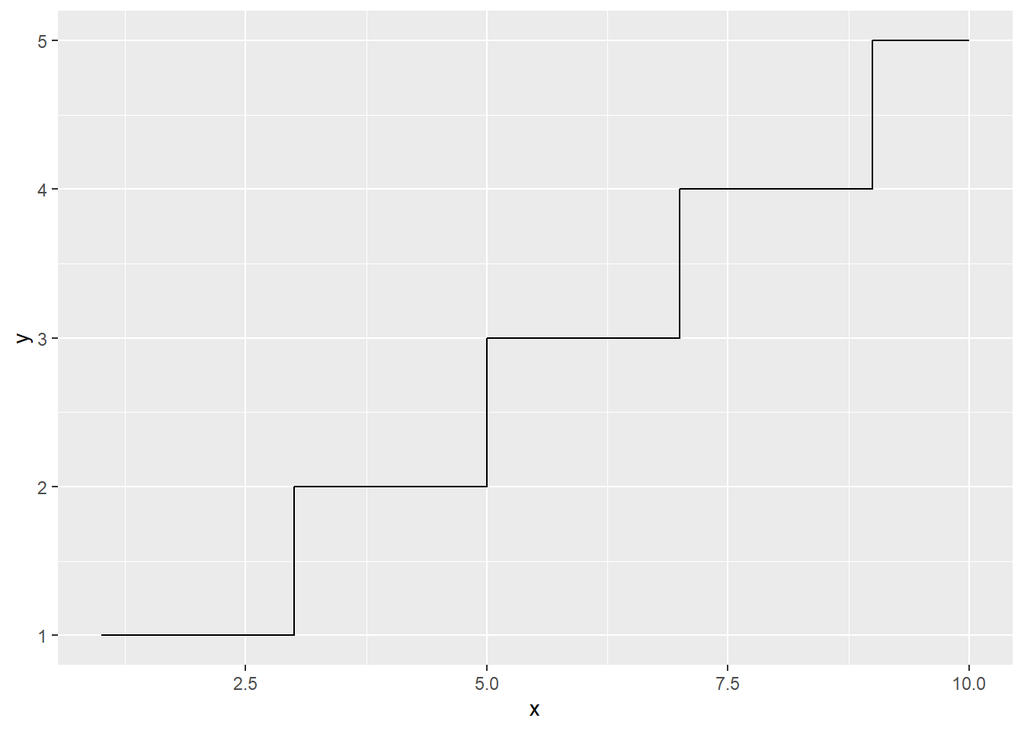

```r
# 阶梯图
df <- data.frame(
  x = 1:10,
  y = c(1, 1, 2, 2, 3, 3, 4, 4, 5, 5)
)
ggplot(df, aes(x = x, y = y)) +
  geom_step()
```

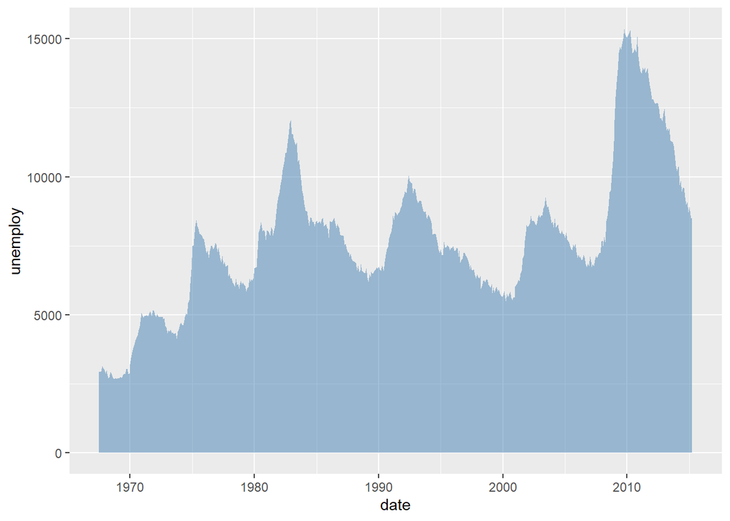

```r
# 面积图
ggplot(economics, aes(x = date, y = unemploy)) +
  geom_area(fill = "steelblue", alpha = 0.5)
```

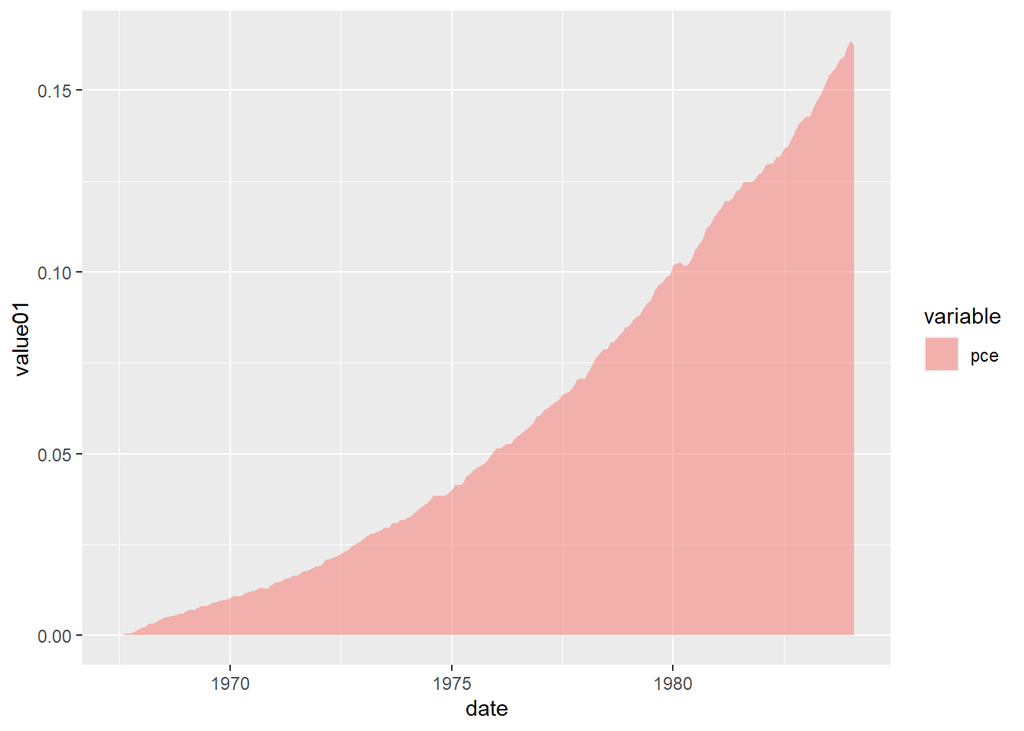

```r
# 堆叠面积图
ggplot(economics_long[1:200, ], aes(x = date, y = value01, fill = variable)) +
  geom_area(alpha = 0.5)
```

**小结**：折线图适合时间序列数据，可以展示趋势和变化。

## 3.3 柱状图

柱状图用于展示分类变量的频数或数值。

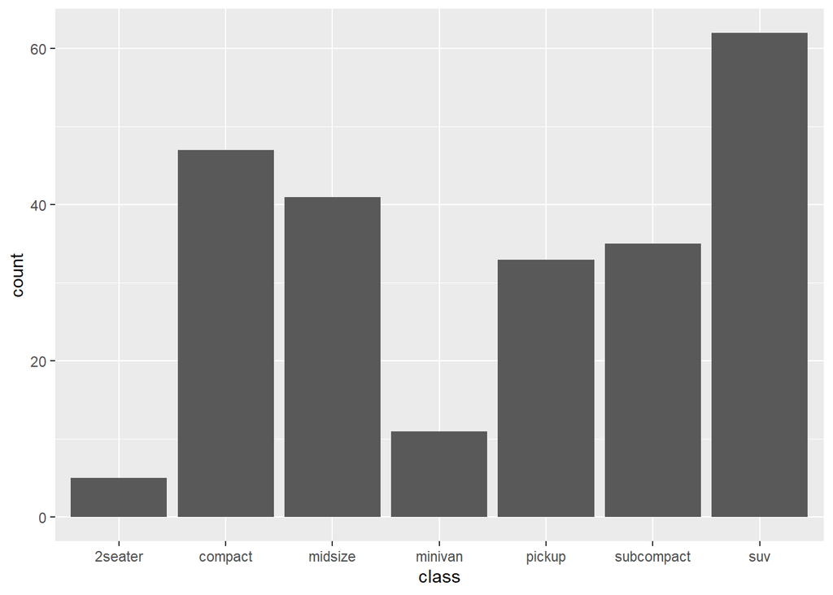

```r
# geom_bar()：自动计数
ggplot(mpg, aes(x = class)) +
  geom_bar()
```

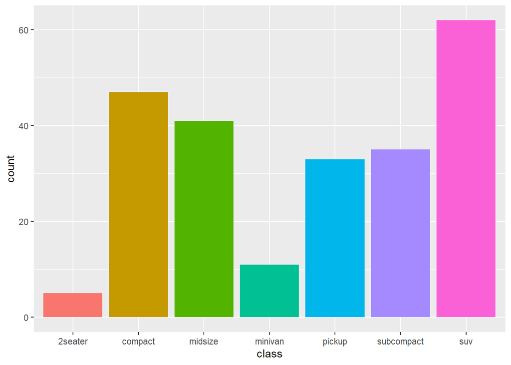

```r
# 添加颜色
ggplot(mpg, aes(x = class, fill = class)) +
  geom_bar() +
  theme(legend.position = "none")
```

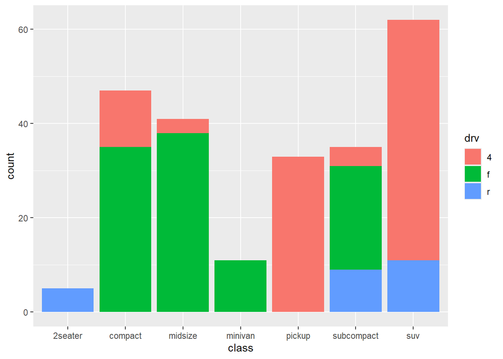

```r
# 堆叠柱状图
ggplot(mpg, aes(x = class, fill = drv)) +
  geom_bar()
```

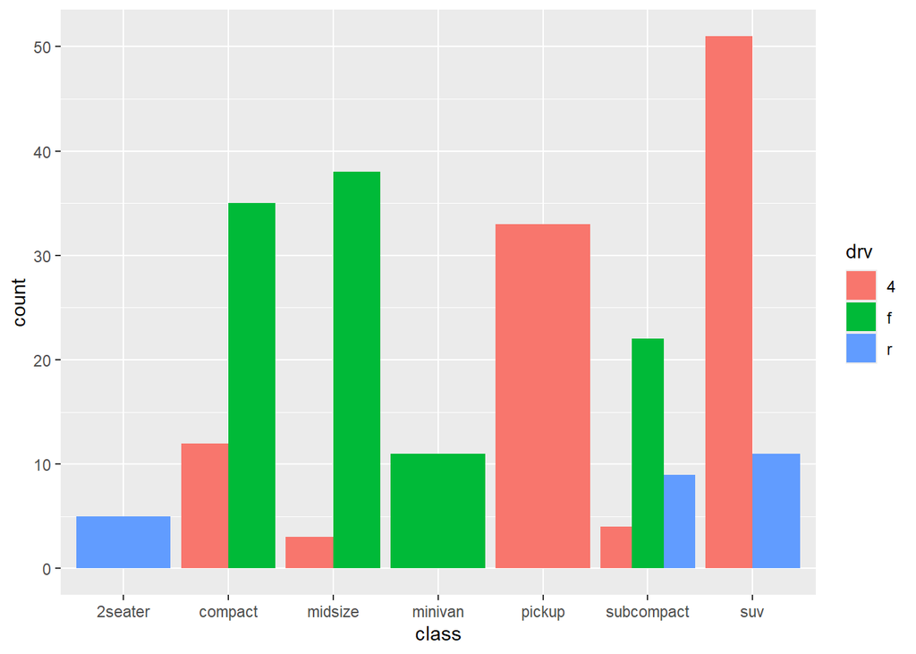

```r
# 分组柱状图
ggplot(mpg, aes(x = class, fill = drv)) +
  geom_bar(position = "dodge")
```

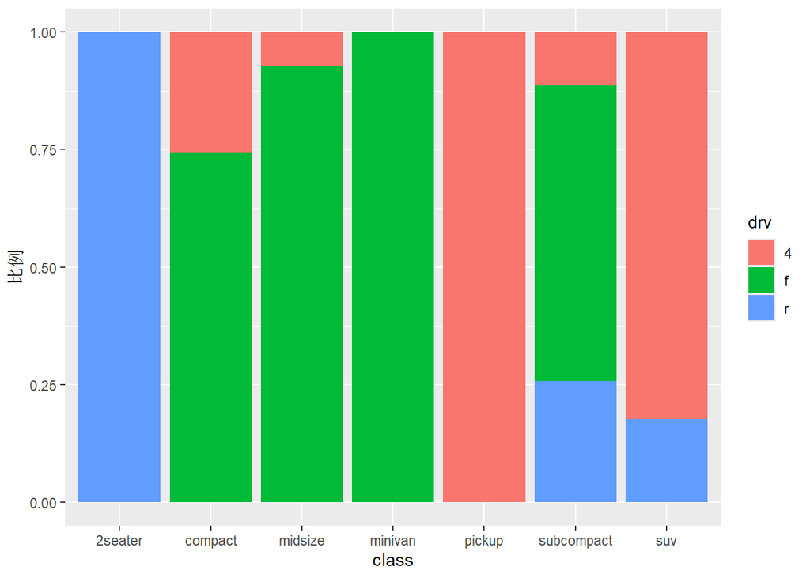

```r
# 百分比堆叠柱状图
ggplot(mpg, aes(x = class, fill = drv)) +
  geom_bar(position = "fill") +
  ylab("比例")
```

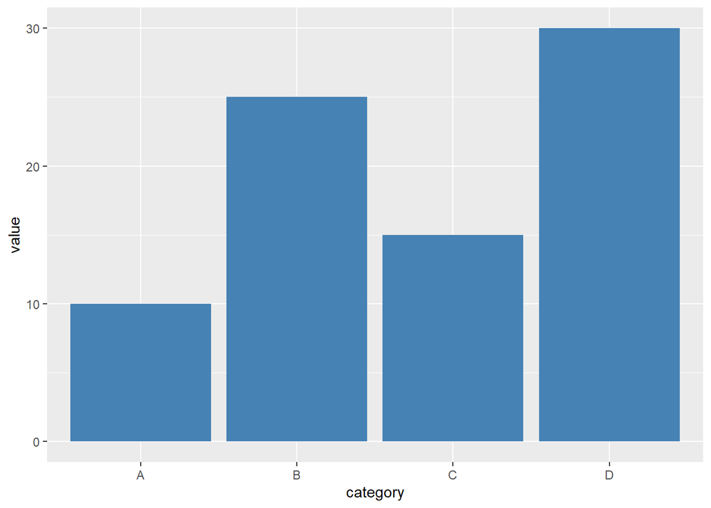

```r
# geom_col()：使用提供的y值
df <- data.frame(
  category = c("A", "B", "C", "D"),
  value = c(10, 25, 15, 30)
)
ggplot(df, aes(x = category, y = value)) +
  geom_col(fill = "steelblue")
```

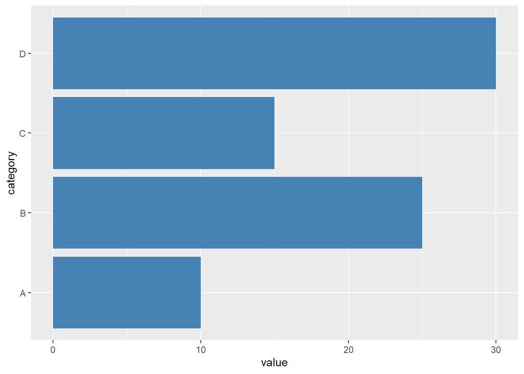

```r
# 水平柱状图
ggplot(df, aes(x = category, y = value)) +
  geom_col(fill = "steelblue") +
  coord_flip()
```

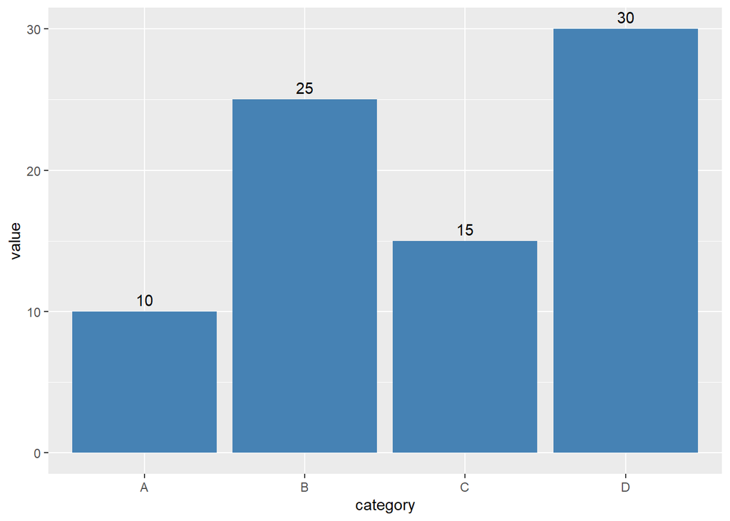

```r
# 添加数值标签
ggplot(df, aes(x = category, y = value)) +
  geom_col(fill = "steelblue") +
  geom_text(aes(label = value), vjust = -0.5)
```

**小结**：`geom_bar()`自动计数，`geom_col()`使用提供的y值。

## 3.4 直方图

直方图用于展示连续变量的分布。

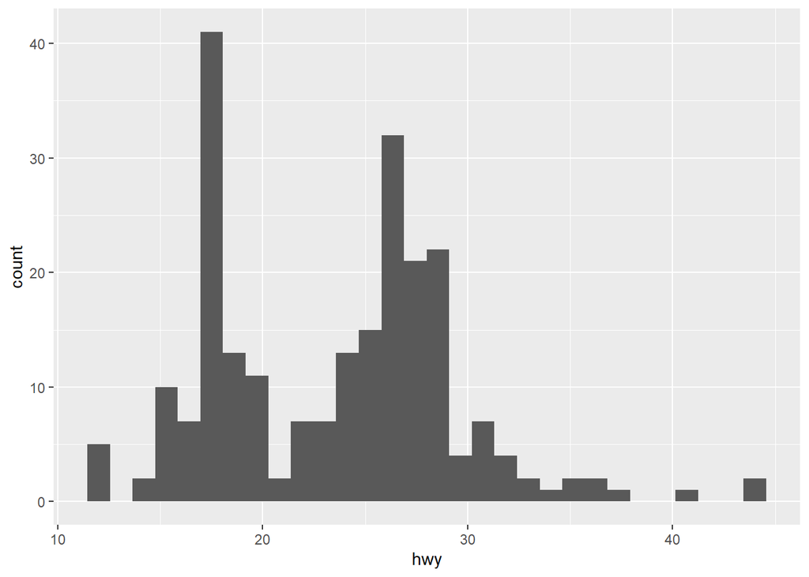

```r
# 基础直方图
ggplot(mpg, aes(x = hwy)) +
  geom_histogram()
```

```r
# 设置分组数量
ggplot(mpg, aes(x = hwy)) +
  geom_histogram(bins = 20)
```

[output not shown]

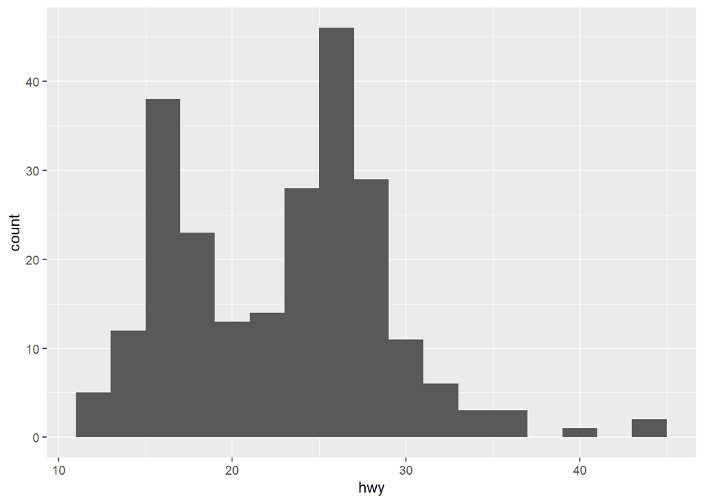

```r
# 设置分组宽度
ggplot(mpg, aes(x = hwy)) +
  geom_histogram(binwidth = 2)
```

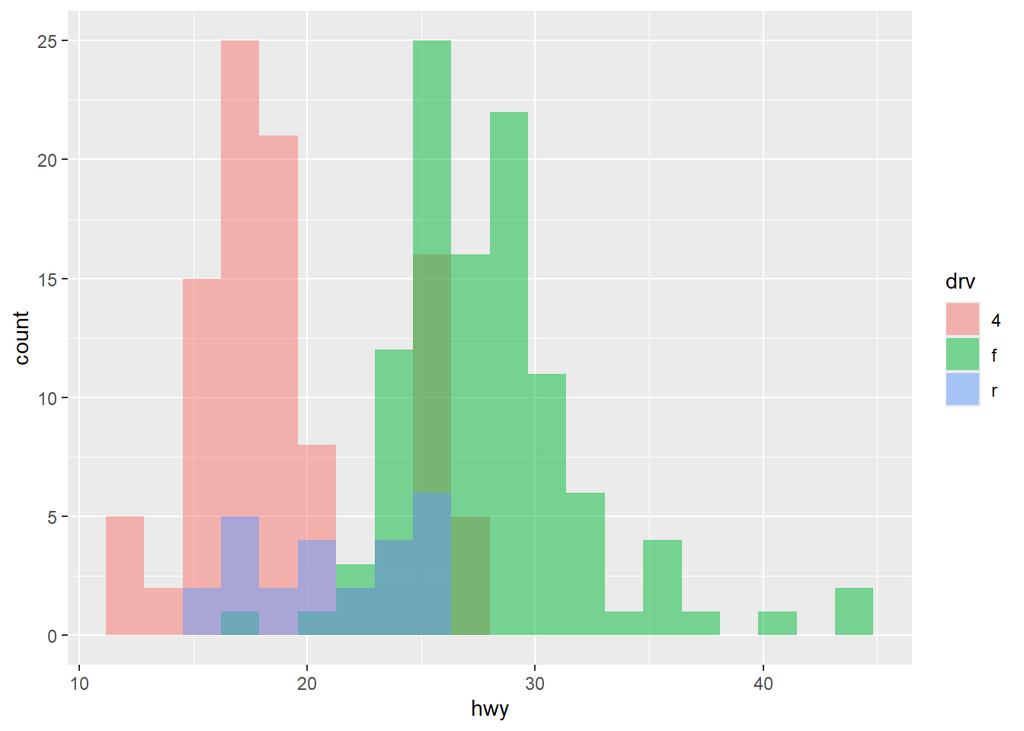

```r
# 添加颜色
ggplot(mpg, aes(x = hwy, fill = drv)) +
  geom_histogram(bins = 20, position = "identity", alpha = 0.5)
```

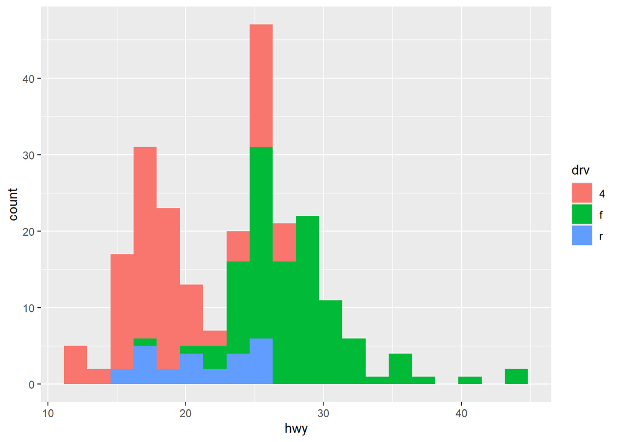

```r
# 堆叠直方图
ggplot(mpg, aes(x = hwy, fill = drv)) +
  geom_histogram(bins = 20)
```

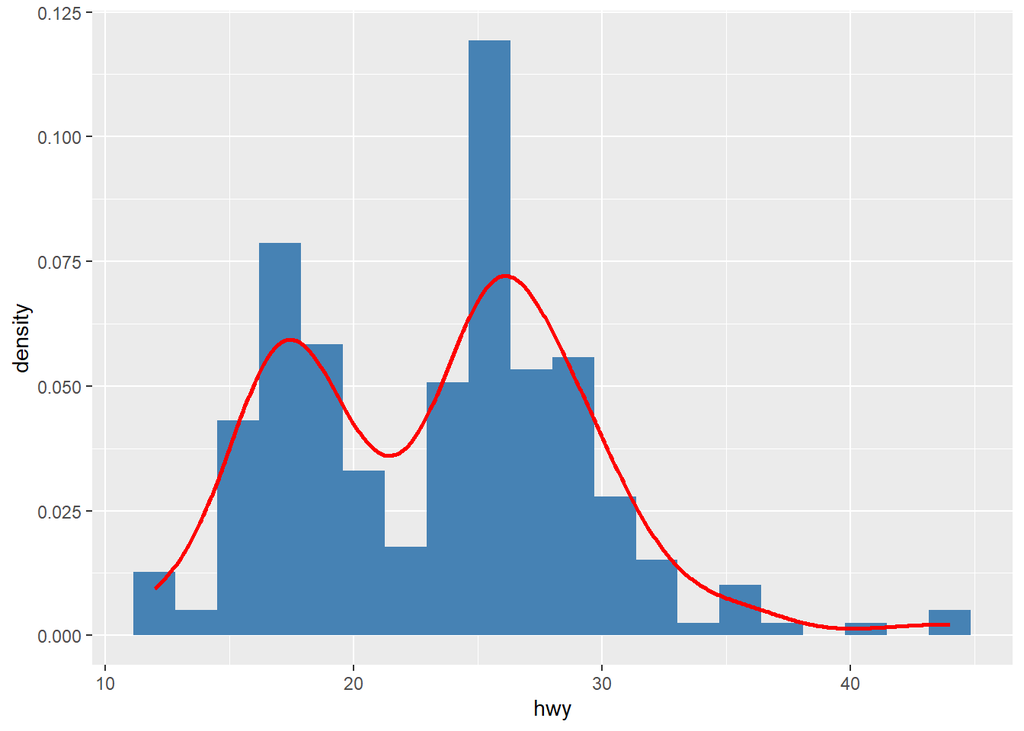

```r
# 添加密度曲线
ggplot(mpg, aes(x = hwy)) +
  geom_histogram(aes(y = after_stat(density)), bins = 20, fill = "steelblue") +
  geom_density(color = "red", linewidth = 1)
```

**小结**：直方图展示数据分布，可通过`bins`或`binwidth`控制分组。

## 3.5 密度图

密度图是直方图的平滑版本。

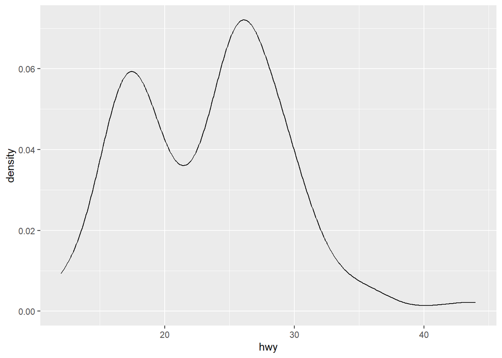

```r
# 基础密度图
ggplot(mpg, aes(x = hwy)) +
  geom_density()
```

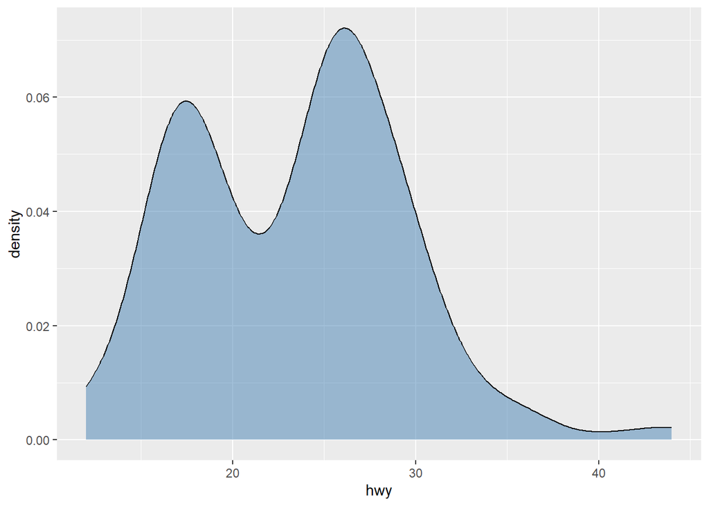

```r
# 填充颜色
ggplot(mpg, aes(x = hwy)) +
  geom_density(fill = "steelblue", alpha = 0.5)
```

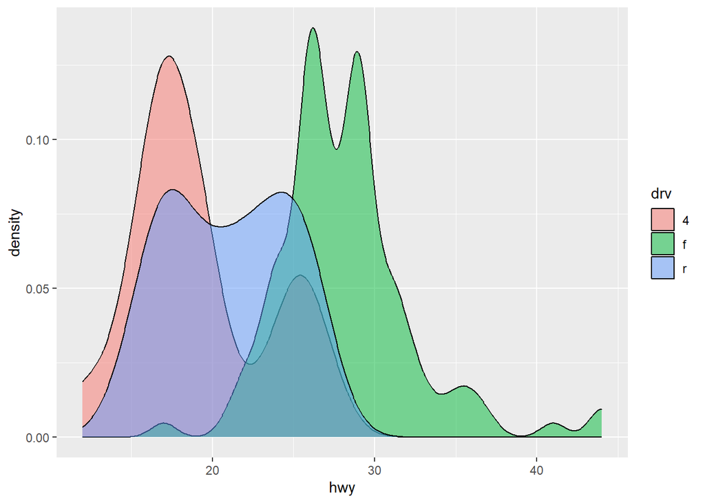

```r
# 按组绘制
ggplot(mpg, aes(x = hwy, fill = drv)) +
  geom_density(alpha = 0.5)
```

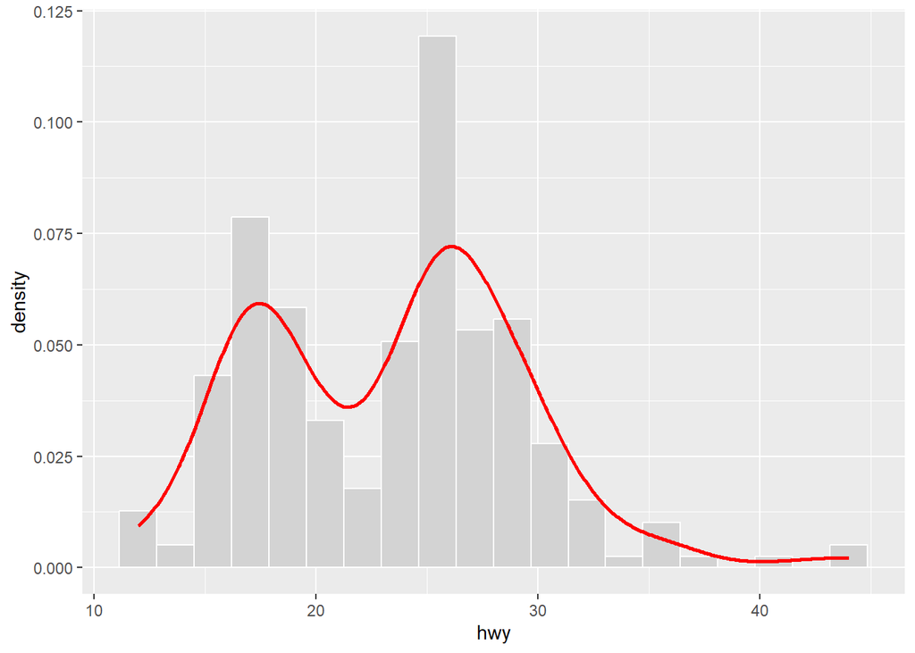

```r
# 直方图+密度图
ggplot(mpg, aes(x = hwy)) +
  geom_histogram(aes(y = after_stat(density)), bins = 20,
                 fill = "lightgray", color = "white") +
  geom_density(color = "red", linewidth = 1)
```

**小结**：密度图是直方图的平滑版本，适合比较多个分布。

## 3.6 箱线图

箱线图用于展示数据分布和异常值。

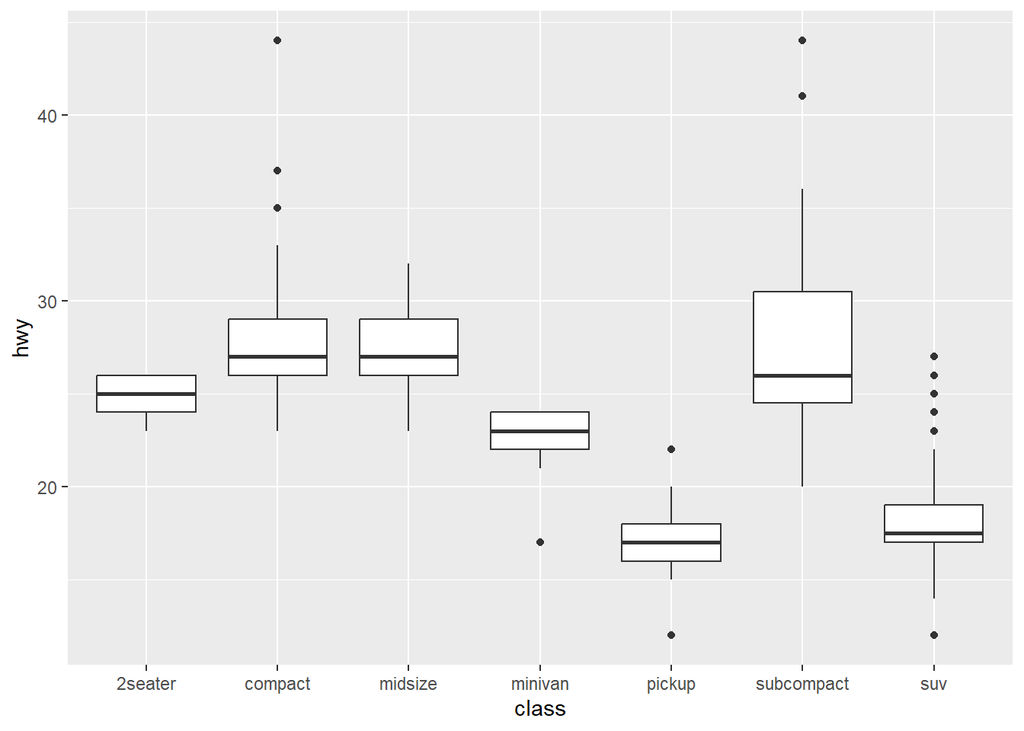

```r
# 基础箱线图
ggplot(mpg, aes(x = class, y = hwy)) +
  geom_boxplot()
```

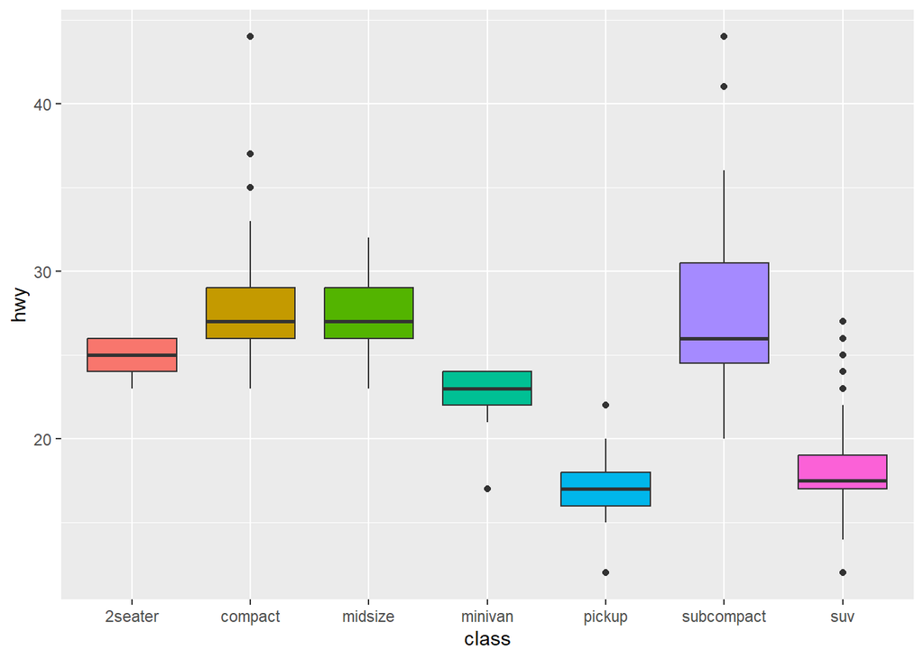

```r
# 添加颜色
ggplot(mpg, aes(x = class, y = hwy, fill = class)) +
  geom_boxplot() +
  theme(legend.position = "none")
```

```r
# 水平箱线图
ggplot(mpg, aes(x = class, y = hwy)) +
  geom_boxplot() +
  coord_flip()
```

[output not shown]

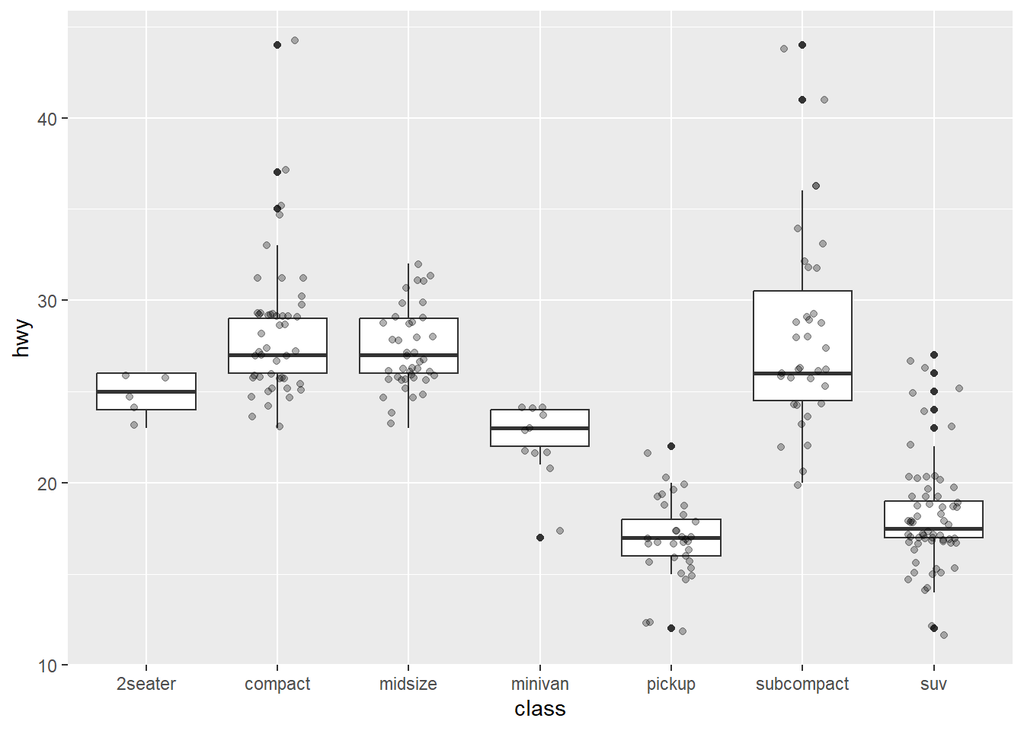

```r
# 添加数据点
ggplot(mpg, aes(x = class, y = hwy)) +
  geom_boxplot() +
  geom_jitter(width = 0.2, alpha = 0.3)
```

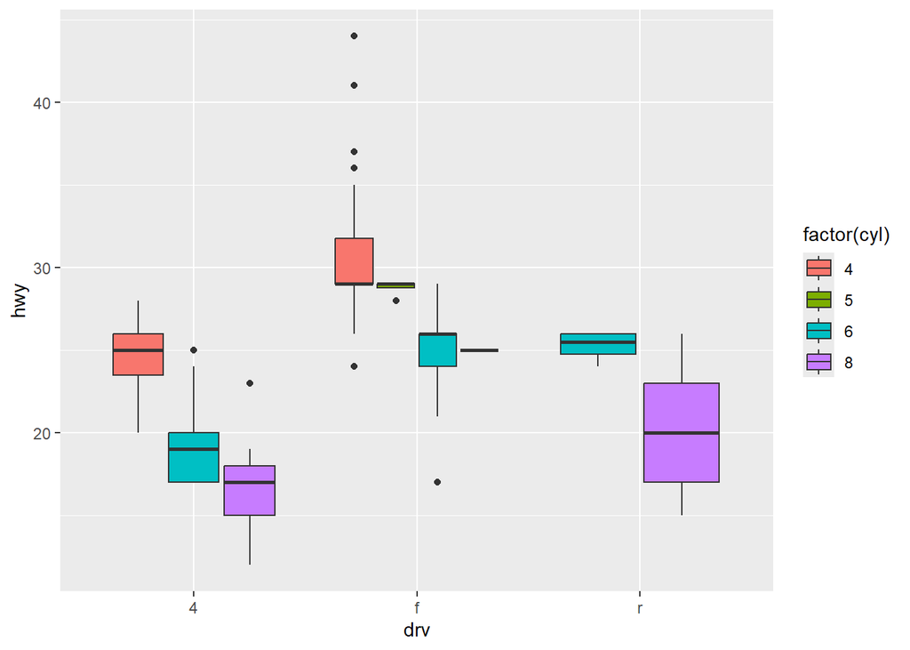

```r
# 按组分组
ggplot(mpg, aes(x = drv, y = hwy, fill = factor(cyl))) +
  geom_boxplot()
```

**小结**：箱线图展示数据分布的五数概括，适合比较多个组。

## 3.7 小提琴图

小提琴图结合了箱线图和密度图。

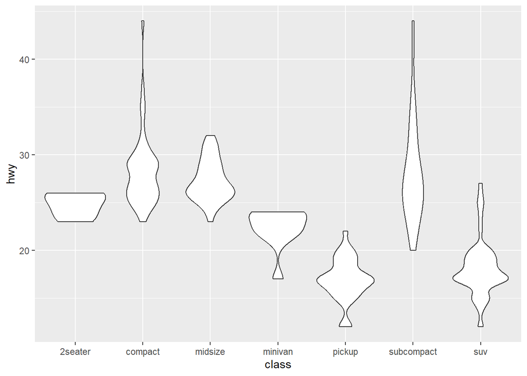

```r
# 基础小提琴图
ggplot(mpg, aes(x = class, y = hwy)) +
  geom_violin()
```

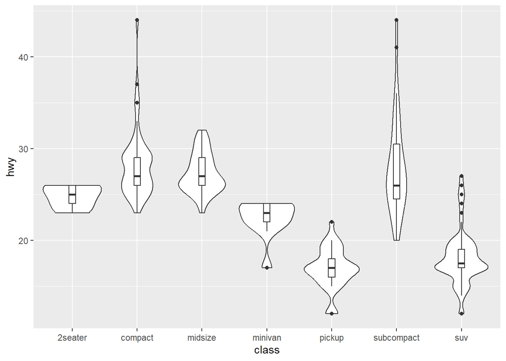

```r
# 添加箱线图
ggplot(mpg, aes(x = class, y = hwy)) +
  geom_violin() +
  geom_boxplot(width = 0.1)
```

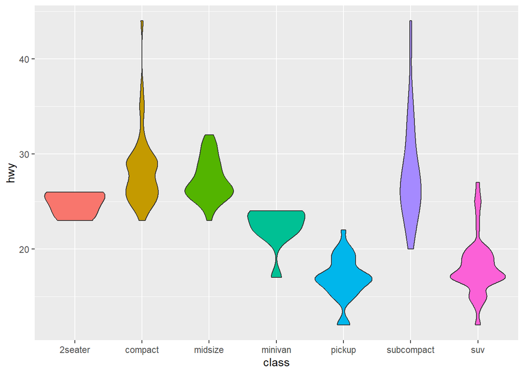

```r
# 添加颜色
ggplot(mpg, aes(x = class, y = hwy, fill = class)) +
  geom_violin() +
  theme(legend.position = "none")
```

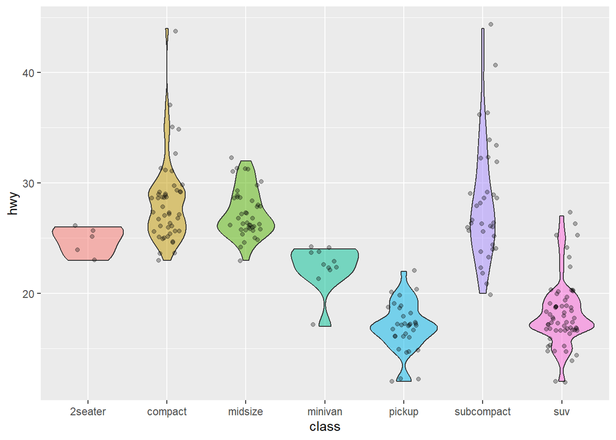

```r
# 小提琴图+数据点
ggplot(mpg, aes(x = class, y = hwy, fill = class)) +
  geom_violin(alpha = 0.5) +
  geom_jitter(width = 0.2, alpha = 0.3) +
  theme(legend.position = "none")
```

**小结**：小提琴图展示完整的分布形状，比箱线图信息更丰富。